# Problema Extra

Mayela Fosado

23/3/2022

### **Redes de interacción proteína-proteína**

Redes de interacción proteína-proteína del paper Evolution of resilence in protein interactomes across the tree of life.

## a) Redes y distribución de conectividades.

**Cargar las redes**

```r
library(igraph)
clavibacter <- read.table("31964.txt")
red_clavibacter <- graph_from_data_frame(clavibacter, directed = T)

magnaporthe <- read.table("148305.txt")
red_magnaporthe <- graph_from_data_frame(magnaporthe, directed = T)

borrelia <- read.table("390236.txt")
red_borrelia <- graph_from_data_frame(borrelia, directed = T)
```

**Distribución de conectividades**

**Clavibacter michiganensis sepedonicus**

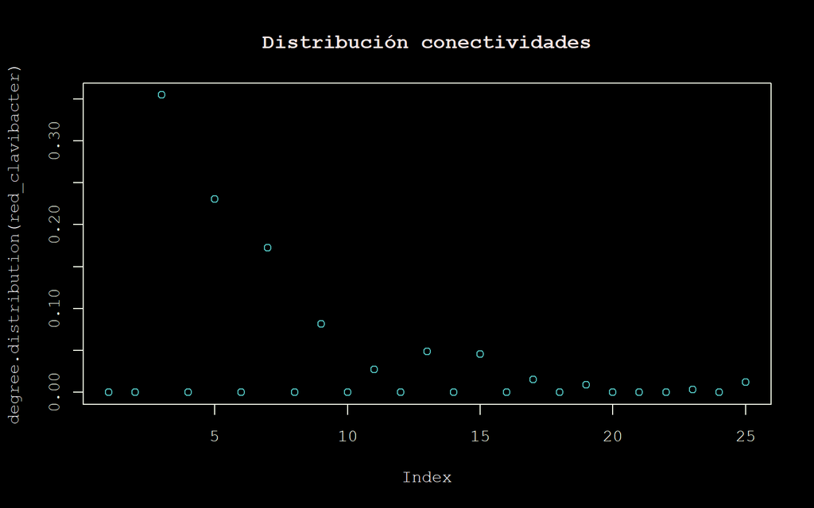

**Magnaporthe grisea**

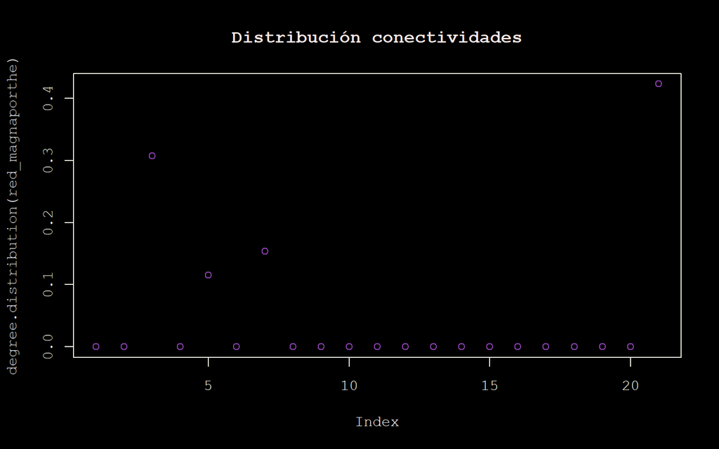

**Borrelia afzelii**

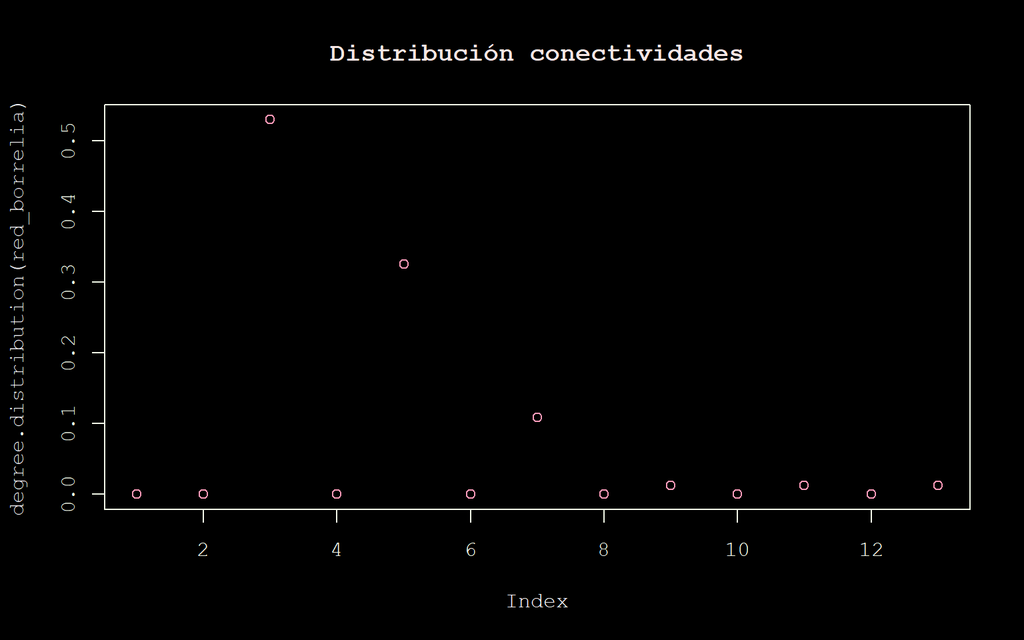

## b) Promedio de las conectividades de las redes

**Clavibacter michiganensis sepedonicus**

```r
mean(degree(red_clavibacter))
```

```
## [1] 5.575758
```

**Magnaporthe grisea**

```r
mean(degree(red_magnaporthe))
```

```
## [1] 10.46154
```

**Borrelia afzelii**

```r
mean(degree(red_borrelia))
```

```
## [1] 3.373494
```

## c) Densidad de las redes.

**Clavibacter michiganensis sepedonicus**

```r
# Opcion 1:
graph.density(red_clavibacter)
```

```
## [1] 0.008473796
```

```r
# Opcion 2:
edge_density(red_clavibacter)
```

```
## [1] 0.008473796
```

**Magnaporthe grisea**

```r
# Opcion 1:
graph.density(red_magnaporthe)
```

```
## [1] 0.2092308
```

```r
# Opcion 2:
edge_density(red_magnaporthe)
```

```
## [1] 0.2092308
```

**Borrelia afzelii**

```r
# Opcion 1:
graph.density(red_borrelia)
```

```
## [1] 0.02057009
```

```r
# Opcion 2:
edge_density(red_borrelia)
```

```
## [1] 0.02057009
```

**Clavibacter michiganensis sepedonicus**

```r
c_10 <- sort(degree(red_clavibacter), decreasing = T)[1:10] # nodos mas conectados

c_10
```

```
## CMS_1625 CMS_2866 CMS_2868 CMS_2869 CMS_0303 CMS_0348 CMS_1820 CMS_1980
##       24       24       24       24       22       18       18       18
## CMS_0069 CMS_0608
##       16       16
```

```r
clav <- red_clavibacter #renombrar los datos

clav <- delete_vertices (clav, sample (c_10)) #remover los nodos de "clav" los datos renombrados

components(clav) # total de componentes
```

```
## $membership
##  CMS_0004  CMS_0016  CMS_0041  CMS_0042  CMS_0067  CMS_0068  CMS_0069  CMS_0098
##         1         2         3         1         4         5         1         2
##  CMS_0108  CMS_0113  CMS_0131  CMS_0132  CMS_0133  CMS_0141  CMS_0153  CMS_0160
##         6         1         7         7         7         1         1         8
##  CMS_0162  CMS_0166  CMS_0181  CMS_0192  CMS_0216  CMS_0233  CMS_0239  CMS_0303
##         1         9         1        10         9         2         1         2
##  CMS_0322  CMS_0348  CMS_0353  CMS_0400  CMS_0422  CMS_0426  CMS_0438  CMS_0449
##         1         1        11        10        12         1        13         6
##  CMS_0488  CMS_0512  CMS_0513  CMS_0517  CMS_0518  CMS_0533  CMS_0535  CMS_0540
##        14         3         3         6         1         2         2         2
##  CMS_0542  CMS_0556  CMS_0581  CMS_0582  CMS_0585  CMS_0586  CMS_0596  CMS_0599
##        15         2         1         1         3         3         3         1
##  CMS_0606  CMS_0607  CMS_0608  CMS_0609  CMS_0612  CMS_0618 CMS_0642C  CMS_0643
##         1         2         1        16        17        16        18         1
##  CMS_0644  CMS_0651  CMS_0695  CMS_0696  CMS_0697  CMS_0698  CMS_0699  CMS_0709
##         1         1         1         1         1         1        19        15
##  CMS_0714  CMS_0723  CMS_0732  CMS_0733  CMS_0734  CMS_0735  CMS_0743  CMS_0773
##         2         2        20        20        20        20        21         2
##  CMS_0775  CMS_0786  CMS_0834  CMS_0845  CMS_0913  CMS_0923  CMS_0966  CMS_1008
##        22        13        23        24         1         1        25        26
##  CMS_1012  CMS_1028  CMS_1031  CMS_1032  CMS_1042  CMS_1044  CMS_1046  CMS_1047
##         1         3         3         3         1         1         1        27
##  CMS_1052  CMS_1059  CMS_1081  CMS_1089  CMS_1091  CMS_1152  CMS_1178  CMS_1193
##        28        18        18         1        26         8         2         1
##  CMS_1197  CMS_1198  CMS_1204  CMS_1216  CMS_1217  CMS_1218  CMS_1231  CMS_1232
##         2         4        22        29        29        19         2         2
##  CMS_1233  CMS_1234  CMS_1235  CMS_1236  CMS_1237  CMS_1249  CMS_1256  CMS_1257
##         2         2         2         2         2         2        24         2
##  CMS_1297  CMS_1312  CMS_1354  CMS_1355  CMS_1357  CMS_1368  CMS_1369  CMS_1370
##         1         2        18         1        20        23        23        23
##  CMS_1371  CMS_1373  CMS_1374  CMS_1386  CMS_1390  CMS_1391  CMS_1413  CMS_1414
##        23        23        23         2         1         1        30        30
##  CMS_1415  CMS_1416  CMS_1420  CMS_1424  CMS_1425  CMS_1428  CMS_1443  CMS_1444
##        30        30         3        30        30        31         1         1
##  CMS_1446  CMS_1447  CMS_1453  CMS_1454  CMS_1455  CMS_1477  CMS_1478  CMS_1479
##         2        10         1        18        14        30        30        30
##  CMS_1493  CMS_1507  CMS_1526  CMS_1539  CMS_1580  CMS_1581  CMS_1602  CMS_1604
##         1         1        13        10        32        32        16         1
##  CMS_1614  CMS_1617  CMS_1619  CMS_1624  CMS_1625  CMS_1640  CMS_1643  CMS_1647
```

[output cut: 36 more lines]

```
##        31        43        43        43        31        31         2         9
##  CMS_2866  CMS_2867  CMS_2868  CMS_2869  CMS_2877  CMS_2879  CMS_2915  CMS_3017
##         1         1         1         1        37        37         1         1
##  CMS_3022  CMS_3030  CMS_3048  CMS_3050  CMS_3054  CMS_3057  CMS_3077  CMS_3078
##         1         2         1         1         1        35         1         1
##  CMS_3079  CMS_3085  CMS_3089  CMS_3090  CMS_3106  CMS_3114
##         1         2         1         1        23        34
##
## $csize
##  [1] 107  52  17   2   2   4   3   3   3   6   4   3   3   2   2   4   2   7   7
## [20]   7   2   2  12   3   3   2   2   2   4  13   9   2   4   4   2   2   3   3
## [39]   2   2   2   3   3
##
## $no
## [1] 43
```

**Magnaporthe grisea**

```r
m_10 <- sort(degree(red_magnaporthe), decreasing = T)[1:10] # nodos mas conectados

m_10
```

```
## A4QSX4 A4QT78 A4QTA3 A4QZL9 A4R0E5 A4R796 A4RDD7 A4RFH6 A4RHN3 A4RK68
##     20     20     20     20     20     20     20     20     20     20
```

```r
mag <- red_magnaporthe #renombrar los datos

mag <- delete_vertices (mag, sample (c_10)) #remover los nodos de "clav" los datos renombrados

components(mag) # total de componentes
```

```
## $membership
## A4QR60 A4QSX4 A4QT54 A4QT78 A4QTA3 A4QTI8 A4QUL1 A4QZL9 A4R0E5 A4R0J5 A4R0J9
##      1      2      3      2      2      3      4      2      2      4      5
## A4R1J7 A4R713 A4R796 A4RD79 A4RF51 A4RHN3 A4RK68 A4RM00 A4RM69 Q51TF7 Q521C0
##      4      1      2      5      6      2      2      3      2      7      7
##
## $csize
## [1] 2 9 3 3 2 1 2
##
## $no
## [1] 7
```

**Borrelia afzelii**

```r
b_10 <- sort(degree(red_borrelia), decreasing = T)[1:10] # nodos mas conectados

b_10
```

```
## BAPKO_0888 BAPKO_0774 BAPKO_0492 BAPKO_0003 BAPKO_0226 BAPKO_0315 BAPKO_0351
##         12         10          8          6          6          6          6
## BAPKO_0433 BAPKO_0656 BAPKO_0846
##          6          6          6
```

```r
bor <- red_borrelia #renombrar los datos

bor <- delete_vertices (bor, sample (c_10)) #remover los nodos de "clav" los datos renombrados

components(bor) # total de componentes
```

```
## $membership
##  BAPKO_0002  BAPKO_0003  BAPKO_0014  BAPKO_0041  BAPKO_0047  BAPKO_0055
##           1           1           2           3           4           1
##  BAPKO_0056  BAPKO_0088  BAPKO_0092  BAPKO_0093  BAPKO_0097  BAPKO_0101
##           5           5           6           6           6           7
##  BAPKO_0102  BAPKO_0110  BAPKO_0130  BAPKO_0153  BAPKO_0204  BAPKO_0214
##           8           9           2           1           7           1
##  BAPKO_0224  BAPKO_0230  BAPKO_0250  BAPKO_0252  BAPKO_0314  BAPKO_0315
##          10          11          12          12           7           7
##  BAPKO_0346  BAPKO_0351  BAPKO_0357  BAPKO_0384  BAPKO_0386  BAPKO_0390
##           5           8           5          13          13           1
##  BAPKO_0424  BAPKO_0425  BAPKO_0433  BAPKO_0463  BAPKO_0467  BAPKO_0492
##           1          14           6          15           1           2
##  BAPKO_0501  BAPKO_0547  BAPKO_0576  BAPKO_0590  BAPKO_0606  BAPKO_0619
##           7          16          17          11           2          13
##  BAPKO_0620  BAPKO_0630  BAPKO_0656  BAPKO_0671  BAPKO_0678  BAPKO_0679
##          18           7           2          14          16          11
##  BAPKO_0686  BAPKO_0702  BAPKO_0716  BAPKO_0727  BAPKO_0728  BAPKO_0730
##          19           5          20           9          21          21
##  BAPKO_0745  BAPKO_0771  BAPKO_0774  BAPKO_0796  BAPKO_0800  BAPKO_0815
##          17           1           1           1          15           7
##  BAPKO_0832  BAPKO_0839  BAPKO_0843  BAPKO_0846  BAPKO_0870  BAPKO_0872
##          16           8           2           2           7           2
##  BAPKO_0884  BAPKO_0888 BafPKo_0041 BafPKo_0046 BafPKo_0092 BafPKo_0163
##           1           1           3           4           6           1
## BafPKo_0220 BafPKo_0371 BafPKo_0601 BafPKo_0644 BafPKo_0696 BafPKo_0833
##          10           8           7          18          20          15
## BafPKo_0840
##          17
##
## $csize
##  [1] 14  8  2  2  5  5  9  4  2  2  3  2  3  2  3  3  3  2  1  2  2
##
## $no
## [1] 21
```

Librería para la función de robustez.

```r
library (brainGraph)
```

**Clavibacter michiganensis sepedonicus**

```r
robustness(clav, measure = "degree")
```

```
##                        type measure comp.size    comp.pct removed.pct
##   1: Targeted vertex attack  degree       107 1.000000000 0.000000000
##   2: Targeted vertex attack  degree       103 0.962616822 0.003067485
##   3: Targeted vertex attack  degree       103 0.962616822 0.006134969
##   4: Targeted vertex attack  degree       102 0.953271028 0.009202454
##   5: Targeted vertex attack  degree       101 0.943925234 0.012269939
##  ---
## 323: Targeted vertex attack  degree         1 0.009345794 0.987730061
## 324: Targeted vertex attack  degree         1 0.009345794 0.990797546
## 325: Targeted vertex attack  degree         1 0.009345794 0.993865031
## 326: Targeted vertex attack  degree         1 0.009345794 0.996932515
## 327: Targeted vertex attack  degree         0 0.000000000 1.000000000
```

**Magnaporthe grisea**

```r
robustness(mag, measure = "degree")
```

```
##                       type measure comp.size  comp.pct removed.pct
##  1: Targeted vertex attack  degree         9 1.0000000  0.00000000
##  2: Targeted vertex attack  degree         8 0.8888889  0.04545455
##  3: Targeted vertex attack  degree         7 0.7777778  0.09090909
##  4: Targeted vertex attack  degree         6 0.6666667  0.13636364
##  5: Targeted vertex attack  degree         5 0.5555556  0.18181818
##  6: Targeted vertex attack  degree         4 0.4444444  0.22727273
##  7: Targeted vertex attack  degree         3 0.3333333  0.27272727
##  8: Targeted vertex attack  degree         3 0.3333333  0.31818182
##  9: Targeted vertex attack  degree         3 0.3333333  0.36363636
## 10: Targeted vertex attack  degree         3 0.3333333  0.40909091
## 11: Targeted vertex attack  degree         3 0.3333333  0.45454545
## 12: Targeted vertex attack  degree         3 0.3333333  0.50000000
## 13: Targeted vertex attack  degree         2 0.2222222  0.54545455
## 14: Targeted vertex attack  degree         2 0.2222222  0.59090909
## 15: Targeted vertex attack  degree         2 0.2222222  0.63636364
## 16: Targeted vertex attack  degree         2 0.2222222  0.68181818
## 17: Targeted vertex attack  degree         2 0.2222222  0.72727273
## 18: Targeted vertex attack  degree         2 0.2222222  0.77272727
## 19: Targeted vertex attack  degree         2 0.2222222  0.81818182
## 20: Targeted vertex attack  degree         2 0.2222222  0.86363636
## 21: Targeted vertex attack  degree         1 0.1111111  0.90909091
## 22: Targeted vertex attack  degree         1 0.1111111  0.95454545
## 23: Targeted vertex attack  degree         0 0.0000000  1.00000000
##                       type measure comp.size  comp.pct removed.pct
```

**Borrelia afzelii**

```r
robustness(bor, measure = "degree")
```

```
##                       type measure comp.size   comp.pct removed.pct
##  1: Targeted vertex attack  degree        14 1.00000000  0.00000000
##  2: Targeted vertex attack  degree         9 0.64285714  0.01265823
##  3: Targeted vertex attack  degree         9 0.64285714  0.02531646
##  4: Targeted vertex attack  degree         9 0.64285714  0.03797468
##  5: Targeted vertex attack  degree         9 0.64285714  0.05063291
##  6: Targeted vertex attack  degree         9 0.64285714  0.06329114
##  7: Targeted vertex attack  degree         9 0.64285714  0.07594937
##  8: Targeted vertex attack  degree         9 0.64285714  0.08860759
##  9: Targeted vertex attack  degree         5 0.35714286  0.10126582
## 10: Targeted vertex attack  degree         5 0.35714286  0.11392405
## 11: Targeted vertex attack  degree         5 0.35714286  0.12658228
## 12: Targeted vertex attack  degree         5 0.35714286  0.13924051
## 13: Targeted vertex attack  degree         5 0.35714286  0.15189873
## 14: Targeted vertex attack  degree         5 0.35714286  0.16455696
```

[output cut: 67 more lines]

Interpretación de los resultados:

La función arroja una tabla con ciertos elementos para comprender el impacto de remover los nodos (en este caso).

**Type:** describe lo que se está analizando.

**Measure:** es la medida en la que se ordenan los vertices, se puede usar random, btwn.cent y degree, en este caso se utilizó degree.

**Comp.size:** el tamaño que queda una vez que se remueven los nodos.

**Comp.pct** la relación entre el tamaño máximo una vez que se remueve.

**Removed.pct:** el impacto de remoción.

## f) 10 proteínas más importantes con su función.

**Clavibacter michiganensis sepedonicus**

```r
sort(betweenness(red_clavibacter), decreasing = T) [1:10]
```

```
## CMS_2456 CMS_1988 CMS_1987 CMS_1980 CMS_1089 CMS_2004 CMS_1939 CMS_2203
## 5833.333 5785.361 5737.333 4793.042 3627.182 3192.000 2706.000 2581.461
## CMS_1932 CMS_2413
## 2151.375 2151.375
```

#### **Proteínas:**

**CMS_2456:** Enolasa

Cataliza la conversión reversible de 2-fosfoglicerato en fosfoenolpiruvato, es importante en la degradación de carbohidratos en la glucólisis.

**CMS_1988:** Gliceraldehído-3-fosfato deshidrogenasa

Enzima importante en la glicólisis y cataliza en el primer paso de la vía, convierte el D-gliceraldehído-3-fosfato eb 3-fosfo-D-glicerol fosfato.

**CMS_1987:** Fosfoglicerato quinasa

Implicada en la subvía que sintetiza piruvato a partir de D-gliceraldehído-3-fosfato, a su vez forma parte de la vía de la glucólisis, y la degradación de carbohidratos.

**CMS_1980:** Glucosa-6-fosfato isomerasa

Cataliza la reacción D-glucosa-6-fosfato a D-fructosa-6-fosfato.

**CMS_1089:** Piruvato deshidrogenasa

Enzima que cataliza la reacción de piruvato y una lipoamida y se forma la dihidrolipoamida acetilada y CO2.

**CMS_2004:** Piruvato quinasa

Participa en el paso 5 de la subvía que sintetiza piruvato a partir dde D-gliceraldehído-3-fosfato.

**CMS_1939:** Fosfoenolpiruvato carboxilasa

Cataliza la adición de bicarbonata al fosfoenolpiruvato y forma el compuesto de cuatro carbonos oxalacetato y fosfato inorgánico.

**CMS_2203:** Citrato sintasa

Participa en el paso 1 de la subvía que sintetiza isocitrato a partir de oxaloacetato.

**CMS_1932:** Putativa aldolasa

Involucrada en la glucólisis, descompone la glucosa en energía.

**CMS_2413** Fructosa-bifosfato aldolasa

Cataliza la condensación aldólica del dihidroxiacetona fosfato con G3P y forma fructosa 1,6-bifosfato en la gluconeogénesis y la reacción inversa de la glucólisis.

**Magnaporthe grisea**

```r
sort(betweenness(red_magnaporthe), decreasing = T) [1:10]
```

```
## A4QR60 A4QSX4 A4QT54 A4QT78 A4QTA3 A4QTI8 A4QUL1 A4QZL9 A4R0E5 A4R0J5
##      0      0      0      0      0      0      0      0      0      0
```

#### **Proteínas:**

**A4QR60:** Glucosa-6-fosfato isomerasa

Cataliza la isomerización reversible de la glucosa-6-fosfato a fructosa-6-fosfato.

**A4QSX4:** Subunidad C del factor 3 de iniciación de la traducción eucariótica

Parte del complejo factor de iniciación de la traducción eucariotica, importante en la síntesis de proteínas.

**A4QT54:** Distribución y morfología mictocondrial proteína 34

Parte del complejo ERMES/MDM, que sirve de anclaje para conectar el retículo endoplásmico y las mitocondrias.

**A4QTA3:** Subunidad J del factor de iniciación de la traducción eucariota

Componente del complejo de inicio de la traducción eucariota (eIF-3), presente en la síntesis de proteínas.

**A4QTI8:** Distribución y morfología mictocondrial proteína 10

Parte del complejo ERMES/MDM, que sirve de anclaje para conectar el retículo endoplásmico y las mitocondrias.

**A4QUL1:** Proteína de transporte SEC24

Componente del complejo de proteínas de cubierta II, promueven la formación de vesículas de transporte desde el retículo endoplásmico.

**A4QZL9:** Subunidad B del factor de iniciación de la traducción

Componente del complejo de inicio de la traducción eucariota (eIF-3), presente en la síntesis de proteínas.

**A4R0E5:** Subunidad F del factor de iniciación de la traducción

Componente del complejo de inicio de la traducción eucariota (eIF-3), presente en la síntesis de proteínas.

**A4R0J5:** Proteína de membrana integral de ensamblaje de la ATPasa vacuolar VMA21

Necesaria para el ensamblaje del complejo V0 de la ATPasa vacuolar en el retículo endoplásmico.

**Borrelia afzelii**

```r
sort(betweenness(red_borrelia), decreasing = T) [1:10]
```

```
##  BAPKO_0774  BAPKO_0888  BAPKO_0884  BAPKO_0771 BafPKo_0601  BAPKO_0204
##    118.6667     86.0000     50.0000     48.0000     46.0000     40.0000
##  BAPKO_0315  BAPKO_0492  BAPKO_0846  BAPKO_0870
##     40.0000     36.0000     33.0000     28.0000
```

#### **Proteínas:**

**BAPKO_0774:** Glucosa-6-fosfato isomerasa

Cataliza la isomerización reversible de la glucosa-6-fosfato a fructosa-6-fosfato.

**BAPKO_0888:** No caracterizada

**BAPKO_0884:** No caracterizada

**BAPKO_0771:** Proteína de la familia de reparación del DNA por esisión de la superbase HhH-GPD

Involucrada en el empaquetamiento del DNA, con actividad de hidrolasa, actina, participa en la reparación de escisión de bases.

**BAPKO_0601:** UDP-N-acetilmuramoylalanina-D-glutamato

Cataliza la adición de glutamato. Participa en la formación de la pared celular.

**BAPKO_0204:** UDP-N-acetilmuramoyl-tripeptido sintetasa

Cataliza la adición de un aminoácido en la bisíntesis del petidoglicano de la pared celular bacteriana.

**BAPKO_0315:** Proteína de la familia de la poliprenil sintetasa

Con actividad de transferasa e involucrada en la biosítesis de procesos isoprenoides.

**BAPKO_0492:** No caracterizada

**BAPKO_0846:** No caracterizada

**BAPKO_0870:** UDP-N-acetilmuramato-L-alanina ligasa

Involucrado en la formación de la pared celular.

## g) Redes en Cytoscape.

**Clavibacter michiganensis sepedonicus**

[figure not shown]

En la red se pueden observar algunos nodos de diferente color que representan en su mayoría enzimas relacionadas con la glucólisis y que estas se encuentran cercanas entre ellas, por lo que la mayoría de esos nodos pueden estar relacionado a ello.

**Magnaporthe grisea**

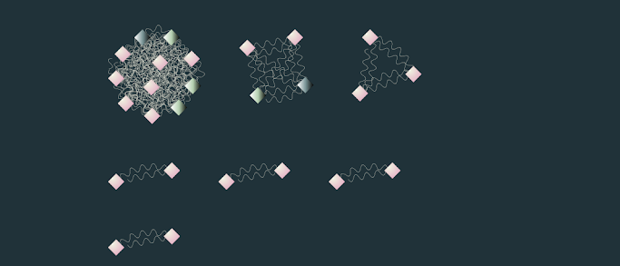

En la red se observan nodos de diferente color los verdes se encuentran relacionados con la traducción y los azules con la distribución y morfología de la mitocondria. A diferencia de las otras redes, esta es una pequeña para poder visualizar de mejor manera cómo se relaciona la función de las proteínas con sus conexiones en la red.

**Borrelia afzelii**

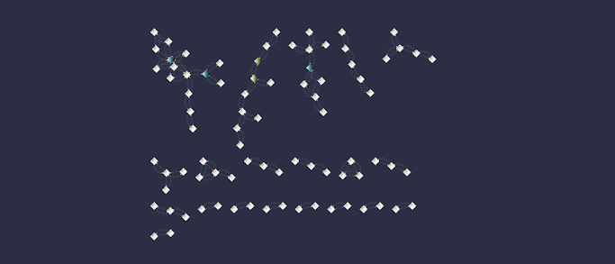

En esta red, se puede observar que destacan 2 colores diferentes, los nodos verdes están relacionados con UDP-N-acetilmuramoyl y los azules son proteínas que no han sido caracterizadas.